# PERTEMUAN 67

Taqi

2023-12-17

```r
### Library

library("forecast")
```

```r
library("graphics")
library("TTR")
library("TSA")
library(dplyr)
library(forecast)
library(lmtest)
library(orcutt)
library(HoRM)
library(corrplot)
library(dLagM)
library(dynlm)
library(MLmetrics)
library(ggplot2)
library(tsibble)
library(tseries)
library(MASS)
library(aTSA)
```

# Input Data

```r
Data <- rio::import("https://raw.githubusercontent.com/Taqiiiii/mpdw1/main/pertemuan%2067/data%20suhu%20fix.csv")
Data
```

```
##        periode  suhu
## 1   11/04/2022 25.60
## 2   12/04/2022 26.15
## 3   13/04/2022 26.31
## 4   14/04/2022 26.58
## 5   15/04/2022 26.31
## 6   16/04/2022 26.60
## 7   17/04/2022 26.95
## 8   18/04/2022 25.96
## 9   19/04/2022 26.07
## 10  20/04/2022 26.01
## 11  21/04/2022 25.99
## 12  22/04/2022 26.92
## 13  23/04/2022 26.44
## 14  24/04/2022 25.93
```

[output cut: 86 more lines]

### Mengubah Data: Data Deret Waktu (Time Series)

```r
Data.ts <- ts(Data$suhu)
Data.ts
```

```
## Time Series:
## Start = 1
## End = 100
## Frequency = 1
##   [1] 25.60 26.15 26.31 26.58 26.31 26.60 26.95 25.96 26.07 26.01 25.99 26.92
##  [13] 26.44 25.93 25.08 26.17 26.74 26.40 26.41 26.74 26.83 26.73 26.01 26.30
##  [25] 27.40 27.59 27.05 27.12 26.77 27.40 26.36 27.09 27.08 27.57 26.94 26.30
##  [37] 26.55 26.89 26.43 26.54 26.25 26.09 26.19 26.32 25.34 25.57 26.25 25.65
##  [49] 26.07 26.16 26.60 26.87 25.61 25.91 26.00 26.16 25.48 26.08 25.88 25.98
##  [61] 26.20 26.09 25.48 26.24 26.05 25.55 25.49 25.33 26.29 26.17 25.51 25.39
##  [73] 25.61 25.69 25.58 25.29 26.00 27.00 26.48 25.78 25.13 25.43 26.43 26.91
##  [85] 26.85 26.38 26.33 26.61 26.36 26.21 26.12 26.20 25.79 25.75 26.38 26.43
##  [97] 26.71 26.51 27.11 26.93
```

### Membagi Data: Data Latih (80%) dan Data Uji (20%), kemudian dijadikan Time Series

```r
dt.latih <- Data[1:80,2]
dt.latih
```

```
##  [1] 25.60 26.15 26.31 26.58 26.31 26.60 26.95 25.96 26.07 26.01 25.99 26.92
## [13] 26.44 25.93 25.08 26.17 26.74 26.40 26.41 26.74 26.83 26.73 26.01 26.30
## [25] 27.40 27.59 27.05 27.12 26.77 27.40 26.36 27.09 27.08 27.57 26.94 26.30
## [37] 26.55 26.89 26.43 26.54 26.25 26.09 26.19 26.32 25.34 25.57 26.25 25.65
## [49] 26.07 26.16 26.60 26.87 25.61 25.91 26.00 26.16 25.48 26.08 25.88 25.98
## [61] 26.20 26.09 25.48 26.24 26.05 25.55 25.49 25.33 26.29 26.17 25.51 25.39
## [73] 25.61 25.69 25.58 25.29 26.00 27.00 26.48 25.78
```

```r
dt.uji <- Data[81:100,2]
dt.uji
```

```
##  [1] 25.13 25.43 26.43 26.91 26.85 26.38 26.33 26.61 26.36 26.21 26.12 26.20
## [13] 25.79 25.75 26.38 26.43 26.71 26.51 27.11 26.93
```

```r
dt.latih.ts <- ts(dt.latih, frequency = 12)
dt.latih.ts
```

```
##     Jan   Feb   Mar   Apr   May   Jun   Jul   Aug   Sep   Oct   Nov   Dec
## 1 25.60 26.15 26.31 26.58 26.31 26.60 26.95 25.96 26.07 26.01 25.99 26.92
## 2 26.44 25.93 25.08 26.17 26.74 26.40 26.41 26.74 26.83 26.73 26.01 26.30
## 3 27.40 27.59 27.05 27.12 26.77 27.40 26.36 27.09 27.08 27.57 26.94 26.30
## 4 26.55 26.89 26.43 26.54 26.25 26.09 26.19 26.32 25.34 25.57 26.25 25.65
## 5 26.07 26.16 26.60 26.87 25.61 25.91 26.00 26.16 25.48 26.08 25.88 25.98
## 6 26.20 26.09 25.48 26.24 26.05 25.55 25.49 25.33 26.29 26.17 25.51 25.39
## 7 25.61 25.69 25.58 25.29 26.00 27.00 26.48 25.78
```

```r
dt.uji.ts <- ts(dt.uji, frequency = 12)
dt.uji.ts
```

```
##     Jan   Feb   Mar   Apr   May   Jun   Jul   Aug   Sep   Oct   Nov   Dec
## 1 25.13 25.43 26.43 26.91 26.85 26.38 26.33 26.61 26.36 26.21 26.12 26.20
## 2 25.79 25.75 26.38 26.43 26.71 26.51 27.11 26.93
```

# Eksplorasi Data

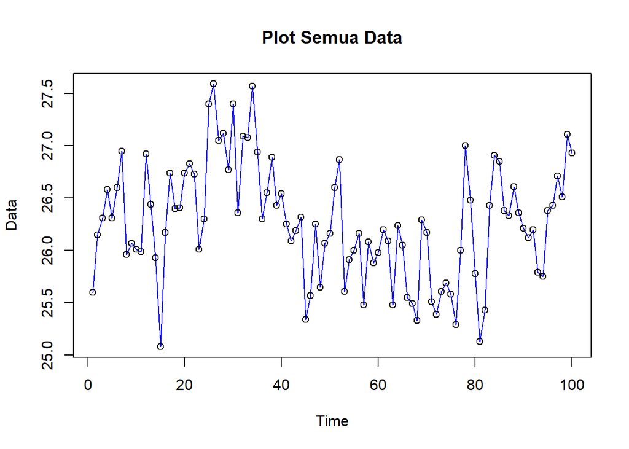

```r
# Semua Data
ts.plot(Data.ts, col = "blue", main = "Plot Semua Data", type = "o", xlab = "Time", ylab = "Data")
points(Data.ts)
```

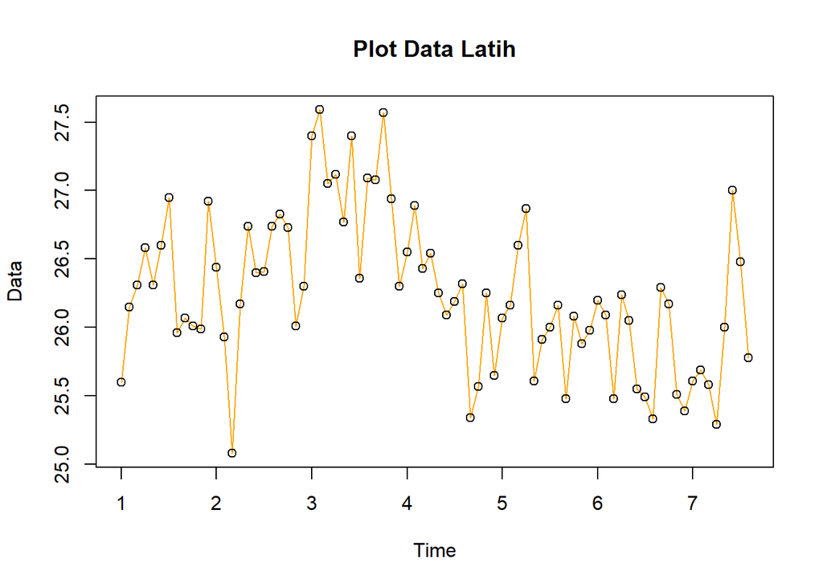

```r
# Data Latih
ts.plot(dt.latih.ts, col = "orange", main = "Plot Data Latih", type = "o", xlab = "Time", ylab = "Data")
points(dt.latih.ts)
```

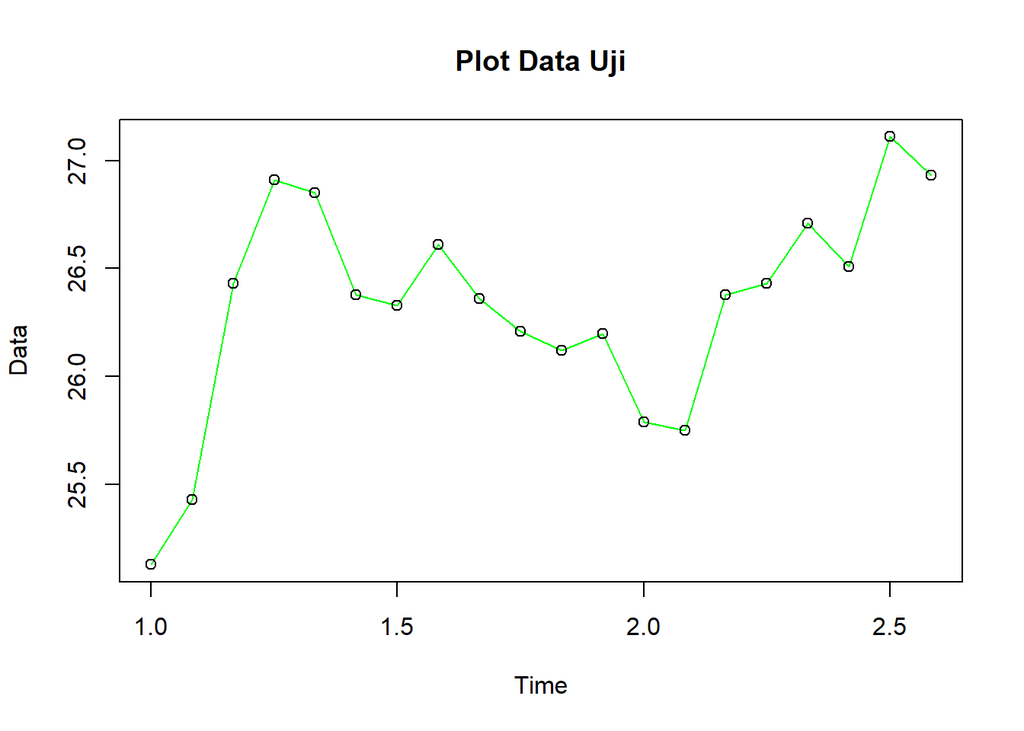

```r
# Data Uji
ts.plot(dt.uji.ts, col = "green", main = "Plot Data Uji", type = "o", xlab = "Time", ylab = "Data")
points(dt.uji.ts)
```

# Cek Kestasioneran Data

### Plot ACF

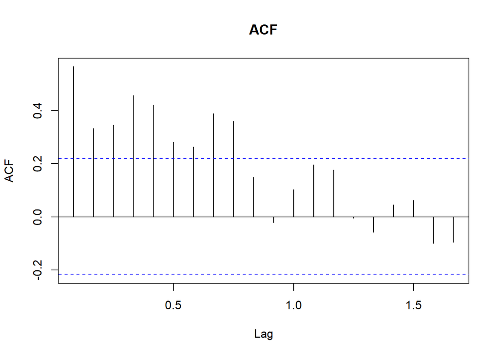

```r
acf(dt.latih.ts, main = "ACF", lag.max = 20)
```

**Interpretasi:** Berdasarkan plot ACF, dapat dilihat bahwa plot ACF pada data tersebut cenderung *tails off* dan tidak membentuk gelombang sinus, menandakan bahwa data tersebut tidak stasioner dalam rataan

### Uji ADF

```r
tseries::adf.test(dt.latih.ts)
```

```
##
##  Augmented Dickey-Fuller Test
##
## data:  dt.latih.ts
## Dickey-Fuller = -2.2063, Lag order = 4, p-value = 0.4913
## alternative hypothesis: stationary
```

# Pengujian Hipotesis

$H_0$ : Data tidak stasioner dalam rataan $H_1$ : Data stasioner dalam rataan

**Interpretasi:** Berdasarkan uji ADF tersebut, diperoleh *p-value* sebesar 0.4913, yang artinya lebih besar dari taraf nyata 5% sehingga tak tolak $H_0$ dan menunjukkan bahwa data tidak stasioner dalam rataan. Hal ini sesuai dengan hasil eksplorasi data menggunakan plot time series dan plot ACF.

### Plot Box-Cox

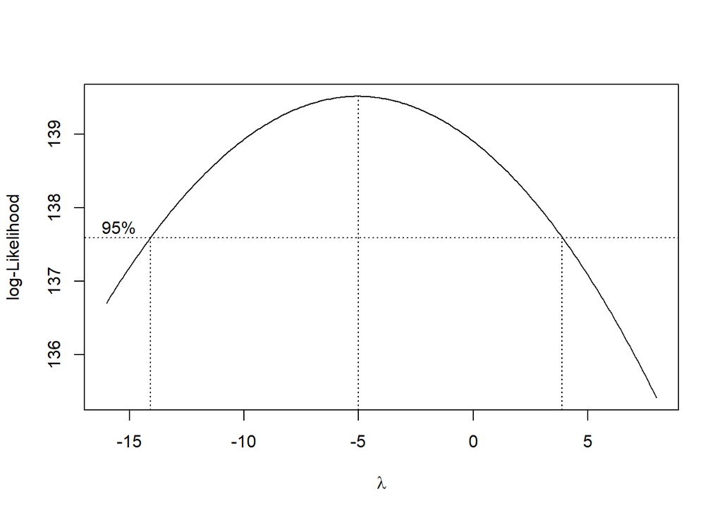

```r
index <- seq(1:80)
bc = boxcox(dt.latih.ts~index, lambda = seq(-16, 8, by = 0.1))
```

```r
# Nilai Rounded Lambda
lambda <- bc$x[which.max(bc$y)]
lambda
```

```
## [1] -5
```

```r
# Selang Kepercayaan (Confidence Interval)
bc$x[bc$y > max(bc$y) - 1/2 * qchisq(.95,1)]
```

```
##   [1] -14.0 -13.9 -13.8 -13.7 -13.6 -13.5 -13.4 -13.3 -13.2 -13.1 -13.0 -12.9
##  [13] -12.8 -12.7 -12.6 -12.5 -12.4 -12.3 -12.2 -12.1 -12.0 -11.9 -11.8 -11.7
##  [25] -11.6 -11.5 -11.4 -11.3 -11.2 -11.1 -11.0 -10.9 -10.8 -10.7 -10.6 -10.5
##  [37] -10.4 -10.3 -10.2 -10.1 -10.0  -9.9  -9.8  -9.7  -9.6  -9.5  -9.4  -9.3
##  [49]  -9.2  -9.1  -9.0  -8.9  -8.8  -8.7  -8.6  -8.5  -8.4  -8.3  -8.2  -8.1
##  [61]  -8.0  -7.9  -7.8  -7.7  -7.6  -7.5  -7.4  -7.3  -7.2  -7.1  -7.0  -6.9
##  [73]  -6.8  -6.7  -6.6  -6.5  -6.4  -6.3  -6.2  -6.1  -6.0  -5.9  -5.8  -5.7
##  [85]  -5.6  -5.5  -5.4  -5.3  -5.2  -5.1  -5.0  -4.9  -4.8  -4.7  -4.6  -4.5
##  [97]  -4.4  -4.3  -4.2  -4.1  -4.0  -3.9  -3.8  -3.7  -3.6  -3.5  -3.4  -3.3
## [109]  -3.2  -3.1  -3.0  -2.9  -2.8  -2.7  -2.6  -2.5  -2.4  -2.3  -2.2  -2.1
## [121]  -2.0  -1.9  -1.8  -1.7  -1.6  -1.5  -1.4  -1.3  -1.2  -1.1  -1.0  -0.9
## [133]  -0.8  -0.7  -0.6  -0.5  -0.4  -0.3  -0.2  -0.1   0.0   0.1   0.2   0.3
## [145]   0.4   0.5   0.6   0.7   0.8   0.9   1.0   1.1   1.2   1.3   1.4   1.5
## [157]   1.6   1.7   1.8   1.9   2.0   2.1   2.2   2.3   2.4   2.5   2.6   2.7
## [169]   2.8   2.9   3.0   3.1   3.2   3.3   3.4   3.5   3.6   3.7   3.8
```

**Interpretasi:** Gambar di atas menunjukkan nilai *rounded value* ($\lambda$) optimum sebesar **-5** dan pada selang kepercayaan 95% nilai memiliki batas bawah **-14.0** dan batas atas **3.8**. Selang tersebut memuat nilai satu, sehingga dapat dikatakan bahwa data bangkitan stasioner dalam ragam.

# Penanganan Ketidakstasioneran Data

```r
# Differencing
train.diff <- diff(dt.latih.ts, differences = 1)
train.diff
```

```
##     Jan   Feb   Mar   Apr   May   Jun   Jul   Aug   Sep   Oct   Nov   Dec
## 1        0.55  0.16  0.27 -0.27  0.29  0.35 -0.99  0.11 -0.06 -0.02  0.93
## 2 -0.48 -0.51 -0.85  1.09  0.57 -0.34  0.01  0.33  0.09 -0.10 -0.72  0.29
## 3  1.10  0.19 -0.54  0.07 -0.35  0.63 -1.04  0.73 -0.01  0.49 -0.63 -0.64
## 4  0.25  0.34 -0.46  0.11 -0.29 -0.16  0.10  0.13 -0.98  0.23  0.68 -0.60
## 5  0.42  0.09  0.44  0.27 -1.26  0.30  0.09  0.16 -0.68  0.60 -0.20  0.10
## 6  0.22 -0.11 -0.61  0.76 -0.19 -0.50 -0.06 -0.16  0.96 -0.12 -0.66 -0.12
## 7  0.22  0.08 -0.11 -0.29  0.71  1.00 -0.52 -0.70
```

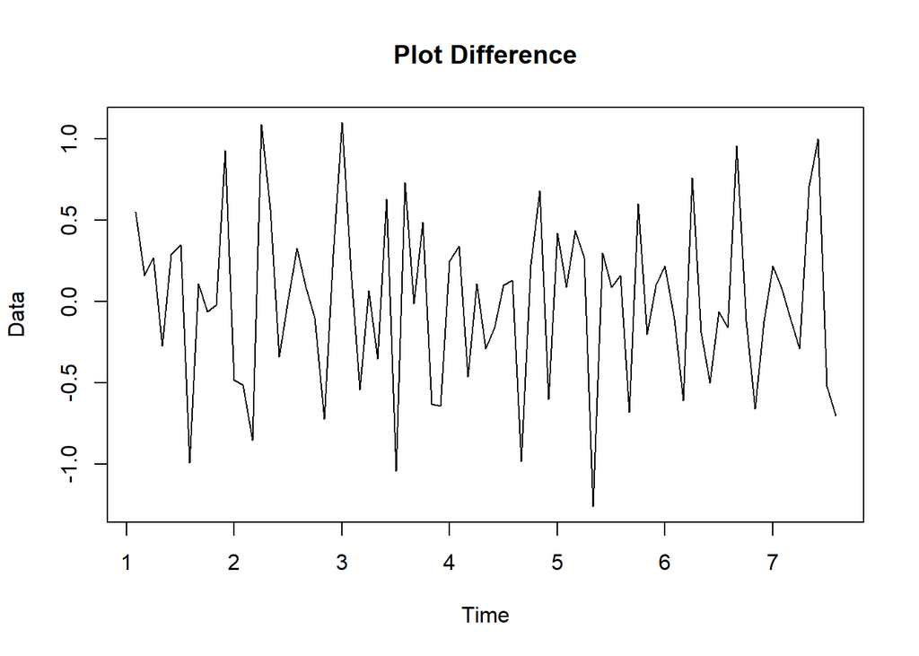

```r
plot.ts(train.diff, lty = 1, xlab = "Time", ylab = "Data", main = "Plot Difference")
```

# Cek Kestasioneran Data (Kembali)

### Plot ACF

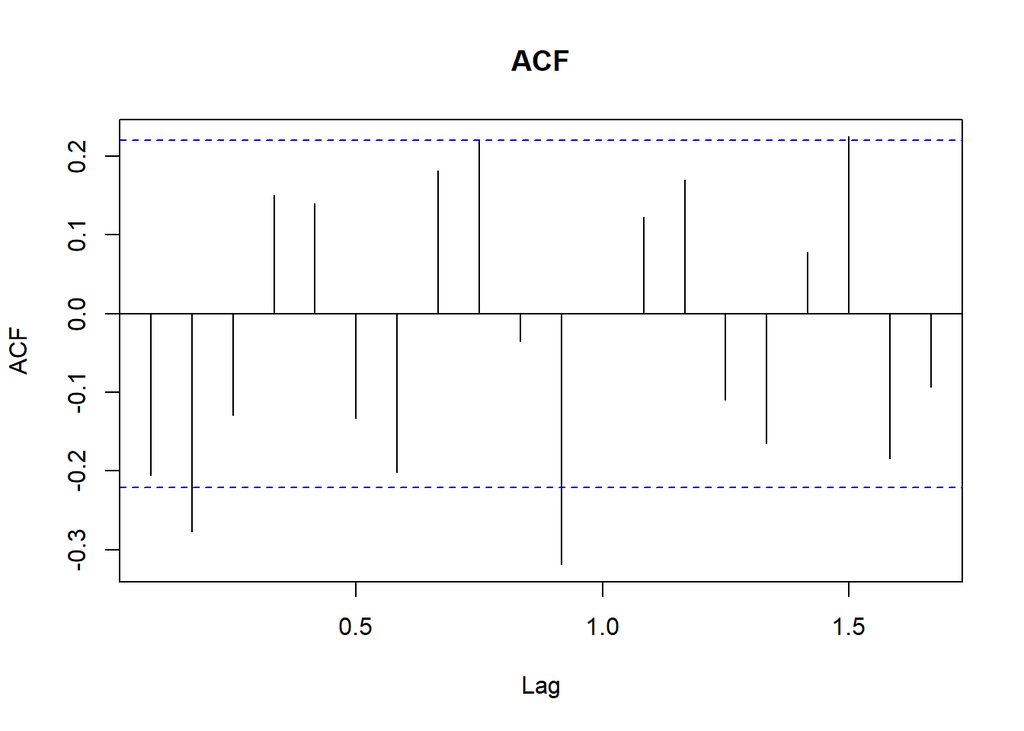

```r
acf(train.diff, main = "ACF", lag.max = 20)
```

**Interpretasi:** Berdasarkan plot ACF, dapat dilihat bahwa plot ACF pada data tersebut cenderung *tails off* dan membentuk gelombang sinus, menandakan bahwa data tersebut sudah stasioner dalam rataan.

### Uji ADF

```r
tseries::adf.test(train.diff)
```

```
##
##  Augmented Dickey-Fuller Test
##
## data:  train.diff
## Dickey-Fuller = -5.1878, Lag order = 4, p-value = 0.01
## alternative hypothesis: stationary
```

**Interpretasi:** Berdasarkan uji ADF kembali, diperoleh *p-value* sebesar 0.01, yang artinya lebih kecil dari taraf nyata 5% sehingga tolak $H_0$ dan menunjukkan bahwa data stasioner dalam rataan. Hal ini sesuai dengan hasil eksplorasi data menggunakan plot time series dan plot ACF.

# Identifikasi Model

### Plot ACF dan PACF

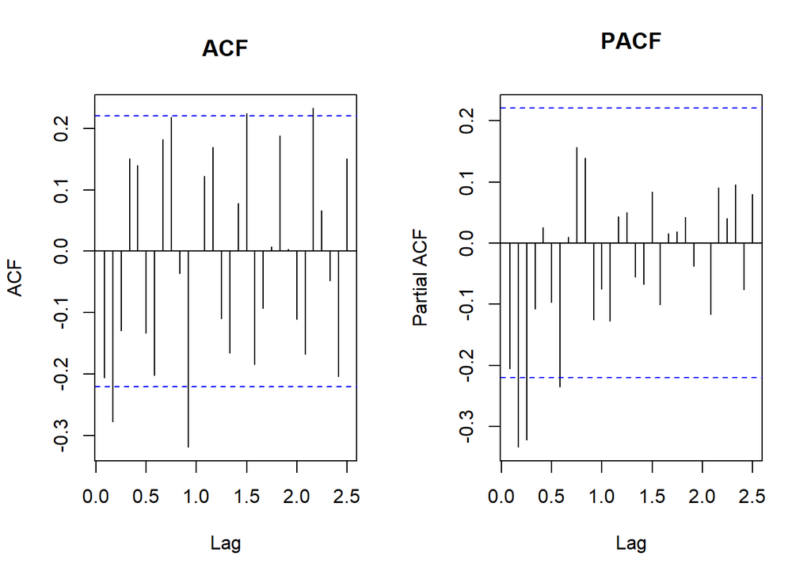

```r
par(mfrow = c(1,2))
acf(train.diff, main = "ACF", lag.max = 30)
pacf(train.diff, main = "PACF", lag.max = 30)
```

### Plot EACF

```r
eacf(train.diff)
```

```
## AR/MA
##   0 1 2 3 4 5 6 7 8 9 10 11 12 13
## 0 o x o o o o o o o o x  o  o  o
## 1 x o o o o o o o x o x  o  o  o
## 2 x x o o o o o o o o o  o  o  o
## 3 x o o o o o o o o o o  o  o  o
## 4 o o o o o o o o o o o  o  o  o
## 5 x o o x o o o o o o o  o  o  o
## 6 x o x o o o o o o o o  o  o  o
## 7 o x x o o o o o o o o  o  o  o
```

**Interpretasi:** Identifikasi model menggunakan plot EACF dilakukan dengan melihat ujung segitiga pada pola segitiga nol. Dalam hal ini model tentatif yang terbentuk adalah ARIMA(2,1,2), dan ARIMA (3,1,1). Sehingga model tentafifnya ialah ARIMA(0,1,1), ARIMA(1,1,0), ARIMA(2,1,2), dan ARIMA(3,1,1).

# Pendugaan Parameter

### ARIMA (0,1,1)

```r
model1 = Arima(train.diff, order = c(0,1,1), method = "ML")
summary(model1) # AIC = 128.74
```

```
## Series: train.diff
## ARIMA(0,1,1)
##
## Coefficients:
##           ma1
##       -1.0000
## s.e.   0.0343
##
## sigma^2 = 0.2776:  log likelihood = -62.37
## AIC=128.74   AICc=128.9   BIC=133.45
##
## Training set error measures:
##                       ME      RMSE       MAE      MPE     MAPE     MASE
## Training set -0.04641351 0.5201192 0.4069958 94.48954 108.6214 0.681207
##                    ACF1
## Training set -0.2038072
```

```r
lmtest::coeftest(model1) # Signifikan
```

```
##
## z test of coefficients:
##
##      Estimate Std. Error z value  Pr(>|z|)
## ma1 -1.000000   0.034348 -29.114 < 2.2e-16 ***
## ---
## Signif. codes:  0 '***' 0.001 '**' 0.01 '*' 0.05 '.' 0.1 ' ' 1
```

### ARIMA (1,1,0)

```r
model2 = Arima(train.diff, order = c(1,1,0), method = "ML")
summary(model2) # AIC = 172.43
```

```
## Series: train.diff
## ARIMA(1,1,0)
##
## Coefficients:
##           ar1
##       -0.4666
## s.e.   0.0991
##
## sigma^2 = 0.5123:  log likelihood = -84.21
## AIC=172.43   AICc=172.59   BIC=177.14
##
## Training set error measures:
##                       ME      RMSE       MAE      MPE     MAPE      MASE
## Training set -0.02156506 0.7066413 0.5678395 92.86611 186.3064 0.9504183
##                    ACF1
## Training set -0.1835784
```

```r
lmtest::coeftest(model2) # Signifikan
```

```
##
## z test of coefficients:
##
##      Estimate Std. Error z value  Pr(>|z|)
## ar1 -0.466583   0.099094 -4.7085 2.496e-06 ***
## ---
## Signif. codes:  0 '***' 0.001 '**' 0.01 '*' 0.05 '.' 0.1 ' ' 1
```

### ARIMA (2,1,2)

```r
model3 = Arima(train.diff, order = c(2,1,2), method = "ML")
summary(model3) # AIC = 113.54
```

```
## Series: train.diff
## ARIMA(2,1,2)
##
## Coefficients:
##          ar1     ar2      ma1     ma2
##       0.2145  -0.279  -1.6565  0.6565
## s.e.  0.1614   0.125   0.1574  0.1492
##
## sigma^2 = 0.212:  log likelihood = -51.77
## AIC=113.54   AICc=114.38   BIC=125.33
##
## Training set error measures:
##                       ME      RMSE       MAE      MPE     MAPE      MASE
## Training set -0.06003369 0.4456277 0.3525888 146.1586 182.1987 0.5901436
##                     ACF1
## Training set -0.03323915
```

```r
lmtest::coeftest(model3) # ada yang tidak signifikan
```

```
##
## z test of coefficients:
##
##     Estimate Std. Error  z value  Pr(>|z|)
## ar1  0.21452    0.16137   1.3294   0.18373
## ar2 -0.27899    0.12503  -2.2314   0.02565 *
## ma1 -1.65652    0.15736 -10.5269 < 2.2e-16 ***
## ma2  0.65652    0.14922   4.3997 1.084e-05 ***
## ---
## Signif. codes:  0 '***' 0.001 '**' 0.01 '*' 0.05 '.' 0.1 ' ' 1
```

### ARIMA (3,1,1)

```r
model4 = Arima(train.diff, order = c(3,1,1), method = "ML")
summary(model4) # AIC = 113
```

```
## Series: train.diff
## ARIMA(3,1,1)
##
## Coefficients:
##           ar1      ar2      ar3      ma1
##       -0.4066  -0.4513  -0.3452  -1.0000
## s.e.   0.1084   0.1061   0.1092   0.0443
##
## sigma^2 = 0.2124:  log likelihood = -51.5
## AIC=113   AICc=113.83   BIC=124.78
##
## Training set error measures:
##                       ME      RMSE       MAE      MPE     MAPE      MASE
## Training set -0.05115222 0.4459983 0.3454779 148.8198 181.9838 0.5782419
##                     ACF1
## Training set -0.04602948
```

```r
lmtest::coeftest(model4) # Signifikan
```

```
##
## z test of coefficients:
##
##      Estimate Std. Error  z value  Pr(>|z|)
## ar1 -0.406570   0.108366  -3.7518 0.0001756 ***
## ar2 -0.451271   0.106126  -4.2522 2.117e-05 ***
## ar3 -0.345192   0.109211  -3.1608 0.0015735 **
## ma1 -0.999997   0.044308 -22.5693 < 2.2e-16 ***
## ---
## Signif. codes:  0 '***' 0.001 '**' 0.01 '*' 0.05 '.' 0.1 ' ' 1
```

**Interpretasi:** Penduga terbaik ialah yang memiliki nilai AIC terkecil dan parameter signifikan, yakni terdapat pada model tentatif ARIMA(3,1,1).

# Analisis Sisaan

### Eksplorasi

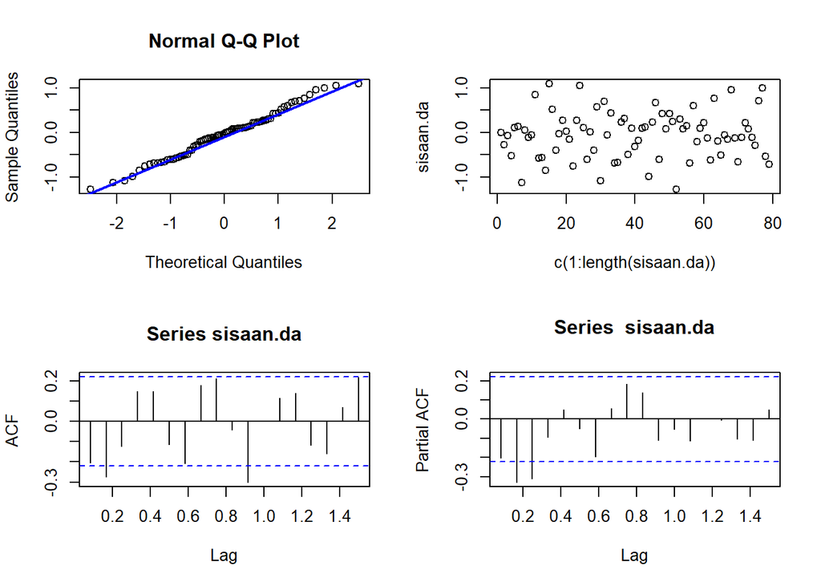

```r
# Eksplorasi
sisaan.da <- model1$residuals
par(mfrow = c(2,2))
qqnorm(sisaan.da)
qqline(sisaan.da, col = "blue", lwd = 2)
plot(c(1:length(sisaan.da)), sisaan.da)
acf(sisaan.da)
pacf(sisaan.da)
```

```r
par(mfrow = c(1,1))
```

### Uji Formal

```r
#1 Sisaan Menyebar Normal
ks.test(sisaan.da,"pnorm")
```

```
##
##  Exact one-sample Kolmogorov-Smirnov test
##
## data:  sisaan.da
## D = 0.18866, p-value = 0.00618
## alternative hypothesis: two-sided
```

# Uji Hipotesis

$H_0$ : Sisaan menyebar normal $H_1$ : Sisaan tidak menyebar normal

```r
#2 Uji Kebebasan Sisaan (Tidak Ada Autokorelasi)
Box.test(sisaan.da, type = "Ljung")
```

```
##
##  Box-Ljung test
##
## data:  sisaan.da
## X-squared = 3.4077, df = 1, p-value = 0.06489
```

# Uji Hipotesis

$H_0$ : Sisaan saling bebas $H_1$ : Sisaan tidak tidak saling bebas

**Interpretasi:** Berdasarkan uji Ljung-Box tersebut, didapat *p-value* sebesar *0.06489* yang lebih besar dari taraf nyata 5% sehingga tak tolak $H_0$ dan menunjukkan bahwa sisaan saling bebas, sehingga tidak ada autokorelasi.

```r
#3 Sisaan Homogen (Homoskedastisitas)
Box.test((sisaan.da)^2, type = "Ljung")
```

```
##
##  Box-Ljung test
##
## data:  (sisaan.da)^2
## X-squared = 0.11455, df = 1, p-value = 0.735
```

# Uji Hipotesis

$H_0$ : Ragam sisaan homogen $H_1$ : Ragam sisaan tidak homogen

**Interpretasi:** Berdasarkan uji Ljung-Box tersebut. diperoleh *p-value* sebesar *0.735* yang lebih besar dari taraf nyata 5% sehingga tak tolak $H_0$ dan menunjukkan bahwa ragam sisaan homogen.

```r
#4 Nilai Tengah Sisaan = 0
t.test(sisaan.da, mu = 0, conf.level = 0.95)  #tak tolak h0 > nilai tengah sisaan sama dengan 0
```

```
##
##  One Sample t-test
##
## data:  sisaan.da
## t = -0.79127, df = 78, p-value = 0.4312
## alternative hypothesis: true mean is not equal to 0
## 95 percent confidence interval:
##  -0.1631905  0.0703635
## sample estimates:
##   mean of x
## -0.04641351
```

# Uji Hipotesis

$H_0$ : nilai tengah sisaan sama dengan 0 $H_1$ : nilai tengah sisaan tidak sama dengan 0

**Interpretasi:** Berdasarkan uji-t tersebut, diperoleh *p-value* sebesar *0.4312* yang lebih besar dari taraf nyata 5% sehingga tak tolak $H_0$ dan menunjukkan bahwa nilai tengah sisaan sama dengan 0.

# Overfitting

### ARIMA(0,1,2)

```r
model5=Arima(train.diff, order = c(0,1,2), method = "ML")
summary(model5) # AIC = 117.97
```

```
## Series: train.diff
## ARIMA(0,1,2)
##
## Coefficients:
##           ma1     ma2
##       -1.6582  0.6582
## s.e.   0.1207  0.1133
##
## sigma^2 = 0.2307:  log likelihood = -55.98
## AIC=117.97   AICc=118.29   BIC=125.04
##
## Training set error measures:
##                       ME      RMSE       MAE     MPE    MAPE     MASE      ACF1
## Training set -0.06115115 0.4711145 0.3709502 78.3635 144.024 0.620876 0.1601455
```

```r
lmtest::coeftest(model5) # Signifikan
```

```
##
## z test of coefficients:
##
##     Estimate Std. Error  z value  Pr(>|z|)
## ma1 -1.65821    0.12074 -13.7340 < 2.2e-16 ***
## ma2  0.65821    0.11334   5.8074 6.343e-09 ***
## ---
## Signif. codes:  0 '***' 0.001 '**' 0.01 '*' 0.05 '.' 0.1 ' ' 1
```

# Peramalan

```r
# Forecasting
ramal <- forecast::forecast(model1, h = 24)
ramal
```

```
##       Point Forecast      Lo 80     Hi 80     Lo 95    Hi 95
## Sep 7    0.002278481 -0.6771419 0.6816988 -1.036805 1.041362
## Oct 7    0.002278481 -0.6771419 0.6816988 -1.036805 1.041362
## Nov 7    0.002278481 -0.6771419 0.6816988 -1.036805 1.041362
## Dec 7    0.002278481 -0.6771419 0.6816988 -1.036805 1.041362
## Jan 8    0.002278481 -0.6771419 0.6816988 -1.036805 1.041362
## Feb 8    0.002278481 -0.6771419 0.6816988 -1.036805 1.041362
## Mar 8    0.002278481 -0.6771419 0.6816988 -1.036805 1.041362
## Apr 8    0.002278481 -0.6771419 0.6816988 -1.036805 1.041362
## May 8    0.002278481 -0.6771419 0.6816988 -1.036805 1.041362
## Jun 8    0.002278481 -0.6771419 0.6816988 -1.036805 1.041362
## Jul 8    0.002278481 -0.6771419 0.6816988 -1.036805 1.041362
## Aug 8    0.002278481 -0.6771419 0.6816988 -1.036805 1.041362
## Sep 8    0.002278481 -0.6771419 0.6816988 -1.036805 1.041362
## Oct 8    0.002278481 -0.6771419 0.6816988 -1.036805 1.041362
## Nov 8    0.002278481 -0.6771419 0.6816988 -1.036805 1.041362
## Dec 8    0.002278481 -0.6771419 0.6816988 -1.036805 1.041362
## Jan 9    0.002278481 -0.6771419 0.6816988 -1.036805 1.041362
## Feb 9    0.002278481 -0.6771419 0.6816988 -1.036805 1.041362
## Mar 9    0.002278481 -0.6771419 0.6816988 -1.036805 1.041362
## Apr 9    0.002278481 -0.6771419 0.6816988 -1.036805 1.041362
## May 9    0.002278481 -0.6771419 0.6816988 -1.036805 1.041362
## Jun 9    0.002278481 -0.6771419 0.6816988 -1.036805 1.041362
## Jul 9    0.002278481 -0.6771419 0.6816988 -1.036805 1.041362
## Aug 9    0.002278481 -0.6771419 0.6816988 -1.036805 1.041362
```

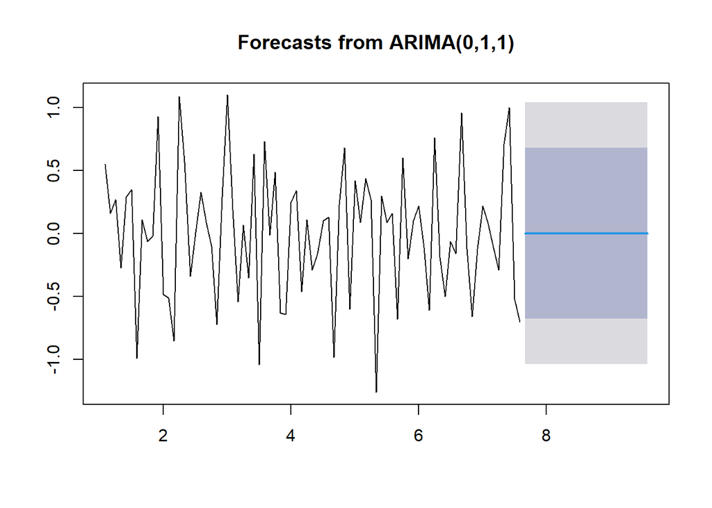

```r
dataramal <- ramal$mean
plot(ramal)
```

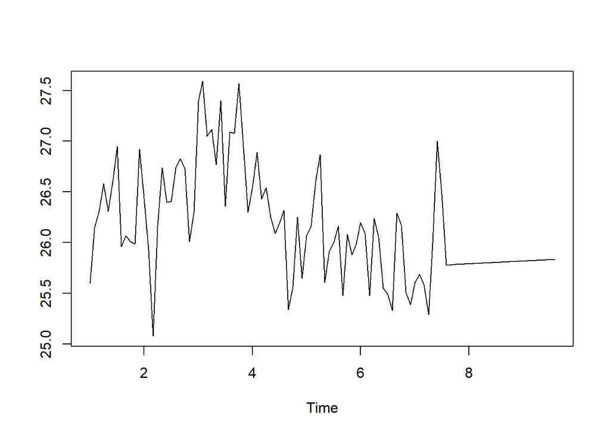

```r
pt.1 <- dt.latih.ts[80]
hasilforc.Diff <- dataramal
hasil <- diffinv(hasilforc.Diff, differences = 1) + pt.1
ts.plot(dt.latih.ts, hasil)
```

# Akurasi

```r
perbandingan <- matrix(data = c(head(dt.uji.ts, n = length(dt.uji)), hasil[-1]),
                     nrow = length(dt.uji), ncol = 2)
colnames(perbandingan) <- c("Aktual", "Hasil Forecast")
perbandingan
```

```
##       Aktual Hasil Forecast
##  [1,]  25.13       25.78228
##  [2,]  25.43       25.78456
##  [3,]  26.43       25.78684
##  [4,]  26.91       25.78911
##  [5,]  26.85       25.79139
##  [6,]  26.38       25.79367
##  [7,]  26.33       25.79595
##  [8,]  26.61       25.79823
##  [9,]  26.36       25.80051
## [10,]  26.21       25.80278
## [11,]  26.12       25.80506
## [12,]  26.20       25.80734
## [13,]  25.79       25.80962
## [14,]  25.75       25.81190
## [15,]  26.38       25.81418
## [16,]  26.43       25.81646
## [17,]  26.71       25.81873
## [18,]  26.51       25.82101
## [19,]  27.11       25.82329
## [20,]  26.93       25.82557
```

```r
accuracy(hasil[-1], head(dt.uji.ts, n = length(dt.uji)))
```

```
##                 ME      RMSE       MAE      MPE     MAPE      ACF1 Theil's U
## Test set 0.5245759 0.7143989 0.6334114 1.958336 2.388969 0.5197082  1.828745
```

[output not shown]